# Portfolio Sarah Nüssler

## Corpus

There are several ways economic prosperity is measured and predicted. From intuitive measures and mathematically complex models (unemployment, inflation, interest rates), to things like skirt length, lipstick sales and the “men’s underwear index”. I wanted to see if music could be a similar recession indicator. While you might think that people tend to listen to more melancholic and low-tempo music during economic turmoil, some quick research into “Recession pop” suggests the opposite. Smart (2025) describes it as “art which is thought to exalt in maximalism, high energy, and optimism as a way of escaping the difficulties that lie outside the walls of the nightclub”. Hanson (2014) similarly links the rise of electronic dance music in 2009-2011 to the global economic crisis. The corpus of music I would like to use to further research this is the top songs from 2004-2007 versus the top songs from 2008-2011.

Hanson, C. F. (2014). Pop Goes Utopia: An Examination of Utopianism in Recent Electronic Dance Pop. Utopian Studies, 25(2), 384–413.

Smart, N. (2025). Bret/BRAT. Critical Quarterly

## Chromagrams

Amy Winehouse — Tears Dry On Their Own:

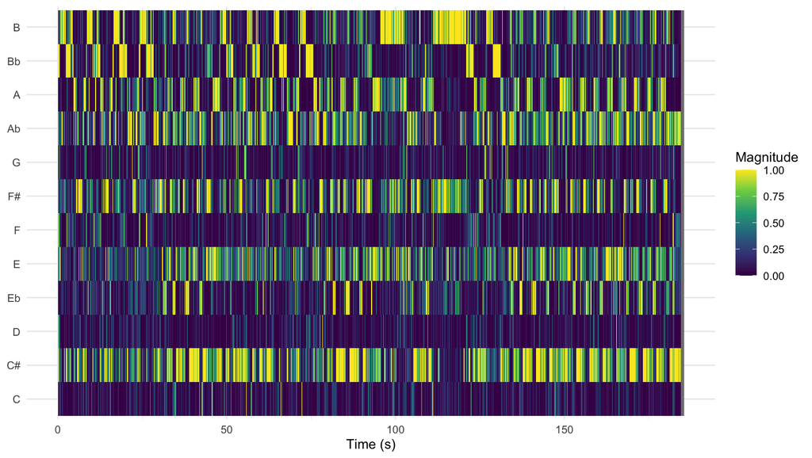

Greenday — American Idiot:

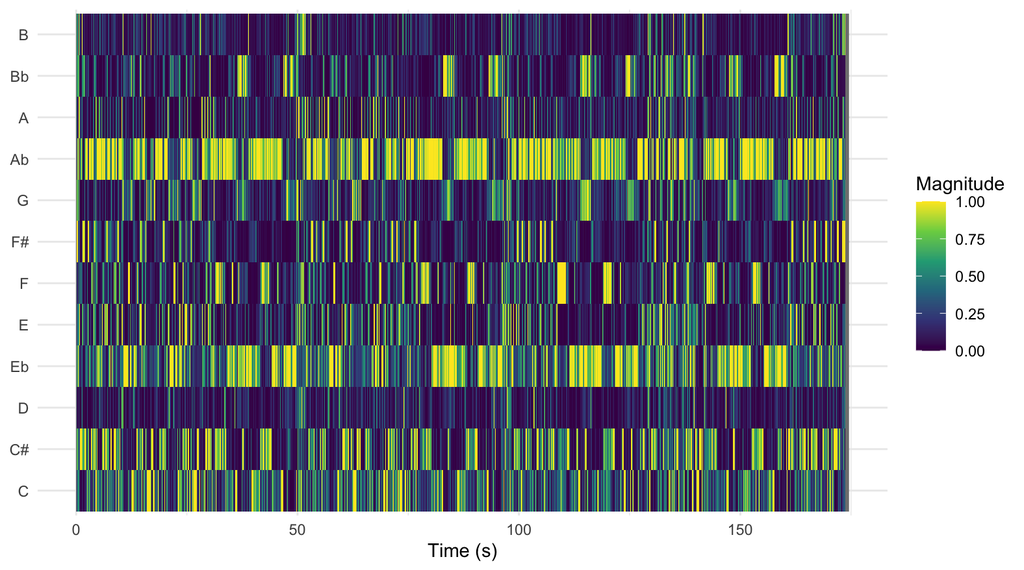

Tears Dry On Their Own displays more varied pitch activity, while American Idiot seems to have a ‘simpler’ construction. You can definitely hear this when listening to both of the songs. Tears Dry Own Their Own has more instruments, it sounds ‘deeper’ and more complex, while American Idiot is much more repetitive and mostly guitar/drums heavy. They’re definitely both very different genres, and that is reflected in the chromagrams.

### Cepstograms

Amy Winehouse — Tears Dry On Their Own:

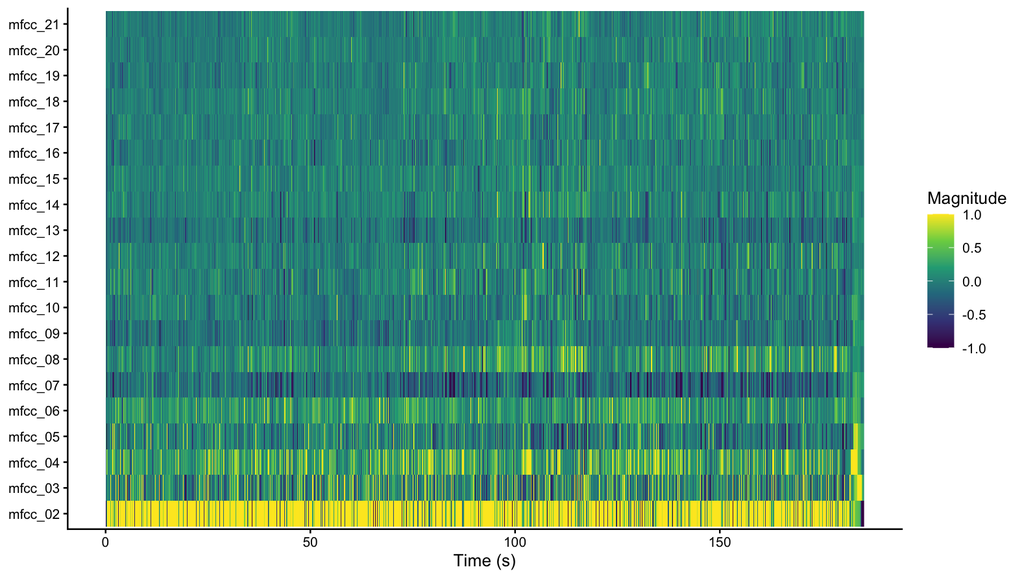

Greenday — American Idiot:

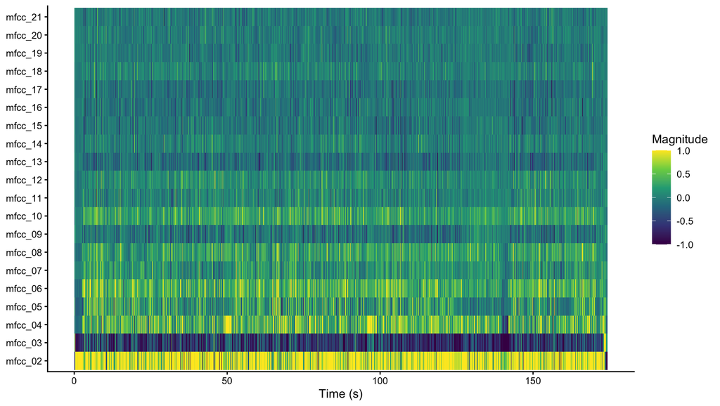